# HW5

StevenChang

10/9/2017

# Part I

```r
library(stats)
library(quantmod)
data = read.csv('wages.csv')
summary(data)
```

```
##    education     south          sex           experience
##  Min.   : 2.00   no :378   Min.   :0.0000   Min.   : 0.00
##  1st Qu.:12.00   yes:156   1st Qu.:0.0000   1st Qu.: 8.00
##  Median :12.00             Median :0.0000   Median :15.00
##  Mean   :13.02             Mean   :0.4588   Mean   :17.82
##  3rd Qu.:15.00             3rd Qu.:1.0000   3rd Qu.:26.00
##  Max.   :18.00             Max.   :1.0000   Max.   :55.00
##      union             wage             age          occupation
##  Min.   :0.0000   Min.   : 1.000   Min.   :18.00   Min.   :1.000
##  1st Qu.:0.0000   1st Qu.: 5.250   1st Qu.:28.00   1st Qu.:3.000
##  Median :0.0000   Median : 7.780   Median :35.00   Median :4.000
##  Mean   :0.1798   Mean   : 9.024   Mean   :36.83   Mean   :4.148
##  3rd Qu.:0.0000   3rd Qu.:11.250   3rd Qu.:44.00   3rd Qu.:6.000
##  Max.   :1.0000   Max.   :44.500   Max.   :64.00   Max.   :6.000
##      sector       marital_status
##  Min.   :0.0000   Min.   :0.0000
##  1st Qu.:0.0000   1st Qu.:0.0000
##  Median :0.0000   Median :1.0000
##  Mean   :0.2753   Mean   :0.6554
##  3rd Qu.:0.0000   3rd Qu.:1.0000
##  Max.   :2.0000   Max.   :1.0000
```

```r
#attach(data)
```

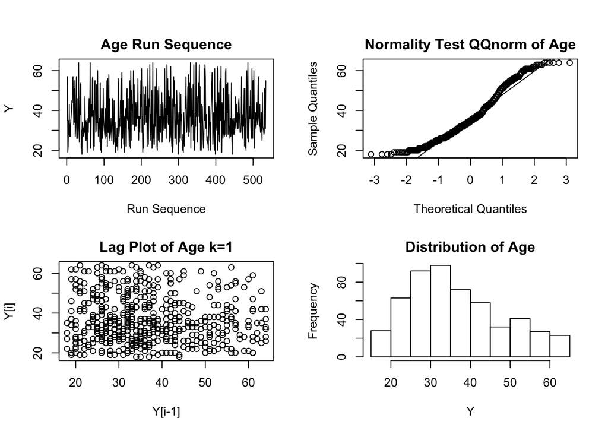

```r
par(mfrow = c(2, 2),
oma = c(0, 0, 2, 0),
mar = c(5.1, 4.1, 2.1, 2.1))

t = 1:length(data$wage)
#AGE

#run sequence
plot(t,data$age,ylab="Y",xlab="Run Sequence",type="l",main="Age Run Sequence")
#qqnorm
qqnorm(data$age,main="Normality Test QQnorm of Age")
qqline(data$age)
#Lag plot
plot(data$age,Lag(data$age, k=1),xlab="Y[i-1]",ylab="Y[i]", main="Lag Plot of Age k=1")
#hitorgram
hist(data$age, xlab="Y", main="Distribution of Age")
```

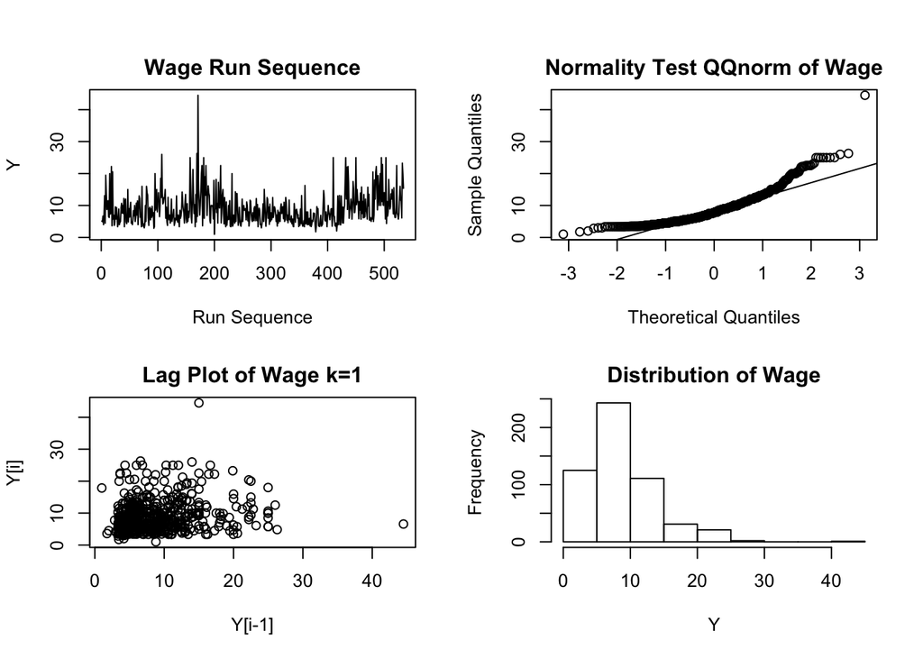

```r
par(mfrow = c(2, 2),
oma = c(0, 0, 2, 0),
mar = c(5.1, 4.1, 2.1, 2.1))
#WAGE

#run sequence
plot(t,data$wage,ylab="Y",xlab="Run Sequence",type="l",main="Wage Run Sequence")
#qqnorm
qqnorm(data$wage,main="Normality Test QQnorm of Wage")
qqline(data$wage)
#Lag plot
plot(data$wage,Lag(data$wage, k=1),xlab="Y[i-1]",ylab="Y[i]", main="Lag Plot of Wage k=1")
#hitorgram
hist(data$wage, xlab="Y", main="Distribution of Wage")
```

(a)(c)wage The data of wage appear to be fairly low while only a very less amount of test subjects is relatively high. Data is not normally distributed, the qqnorm plot trend is not represent as linear, and the histogram is more concentrated to the lower numbers has a right tail.

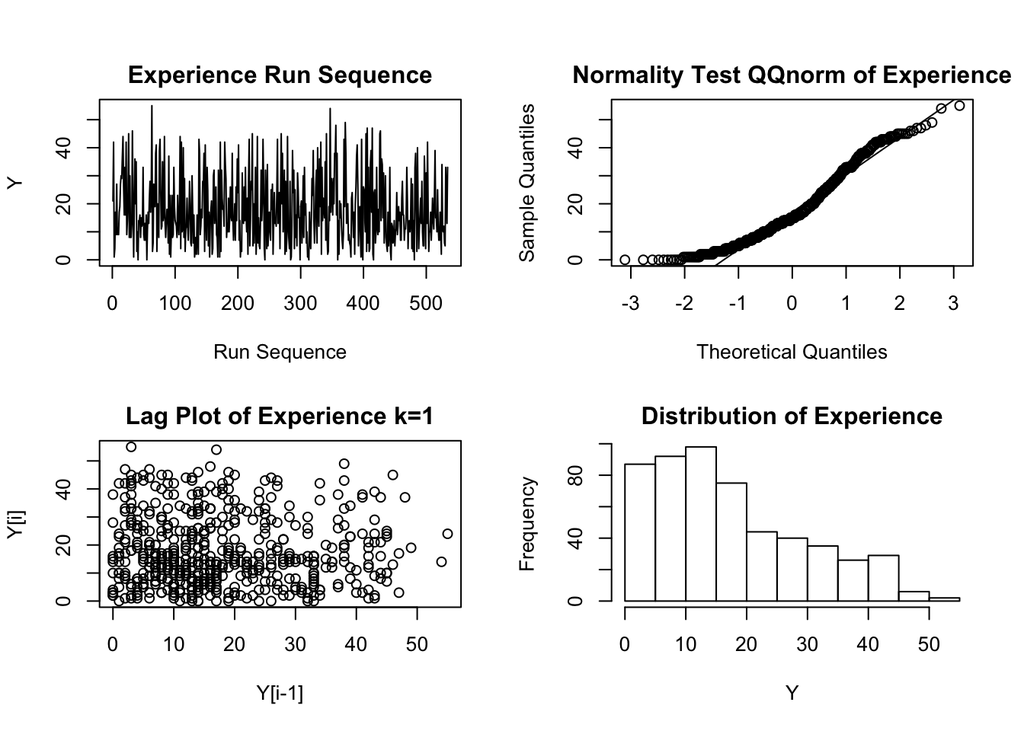

```r
par(mfrow = c(2, 2),
oma = c(0, 0, 2, 0),
mar = c(5.1, 4.1, 2.1, 2.1))
#WAGE

#run sequence
plot(t,data$experience,ylab="Y",xlab="Run Sequence",type="l",main="Experience Run Sequence")
#qqnorm
qqnorm(data$experience,main="Normality Test QQnorm of Experience")
qqline(data$experience)
#Lag plot
plot(data$experience,Lag(data$experience, k=1),xlab="Y[i-1]",ylab="Y[i]", main="Lag Plot of Experience k=1")
#hitorgram
hist(data$experience, xlab="Y", main="Distribution of Experience")
```

(a)(b)Experience The data of exprience appear to be random. Data not normally distributed, the qqnorm plot trend is nearly represent as linear, and the histogram is distributed normally while slighty more concentrated to the lower numbers.

```r
confidence_interval = function(vec, prop = 0.95){
# given feature vec, return confidence interval (default 95%)
CI=list()

p = 1 - (1 - prop) / 2
n = length(vec)
avg = mean(vec)
stdev = sd(vec)
error = qnorm(p)*stdev/sqrt(n)
  # CI$data = vec
CI$mean = avg
CI$stdev = stdev
CI$lower = avg-error
CI$upper = avg+error
return(CI)
}
```

```r
# Age's 95% confidence interval
confidence_interval(data$age)
```

```
## $mean
## [1] 36.83333
##
## $stdev
## [1] 11.72657
##
## $lower
## [1] 35.83873
##
## $upper
## [1] 37.82793
```

```r
# Experence's 95% confidence interval
confidence_interval(data$experience)
```

```
## $mean
## [1] 17.8221
##
## $stdev
## [1] 12.37971
##
## $lower
## [1] 16.7721
##
## $upper
## [1] 18.87209
```

As the confidence interval, 1)Age has a 95% confidence interval for population mean (lower = 35.83873, upper = 37.82793). The parameter for its normal distribution could be mean = 36.83333, stdev = 11.72657. 2)Experience has a 95% confidence interval for population mean (lower = 16.7721, upper = 18.87209). The parameter for its normal distribution could be mean = 17.8221, stdev = 12.37971.

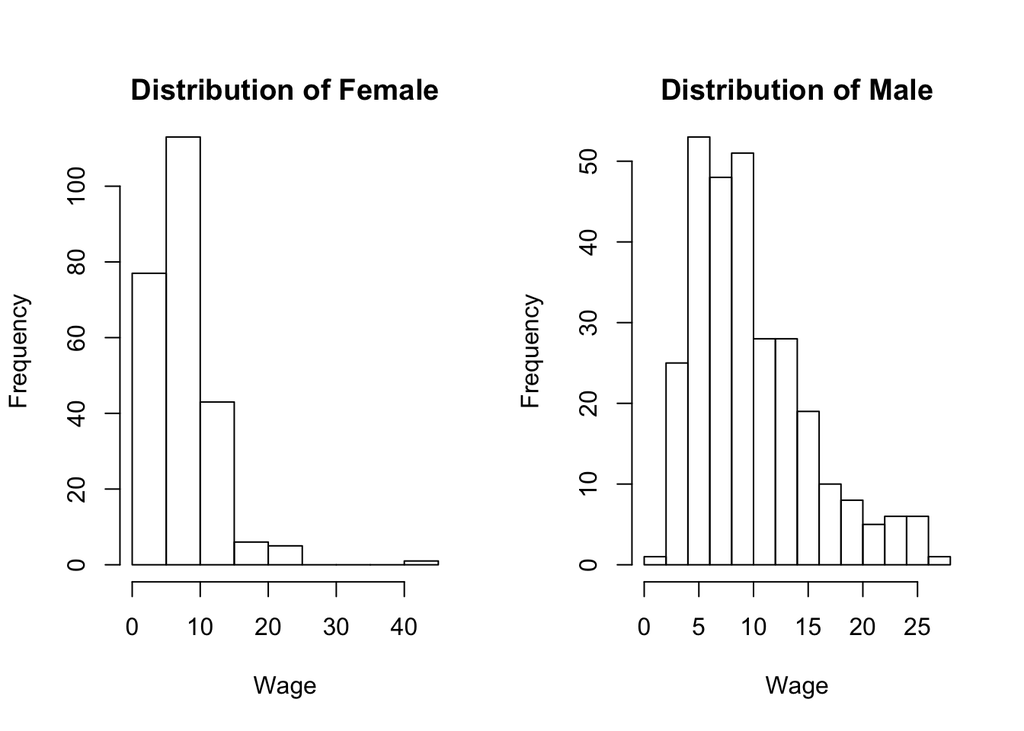

```r
#histogram sex
par(mfrow = c(1, 2),
oma = c(0, 0, 2, 0),
mar = c(5.1, 4.1, 2.1, 2.1))

female <- subset(data,sex=='1')
hist(female$wage, xlab="Wage", main="Distribution of Female")

male <- subset(data,sex=='0')
hist(male$wage, xlab="Wage", main="Distribution of Male")
```

```r
t.test(female$wage,male$wage)
```

```
##
##  Welch Two Sample t-test
##
## data:  female$wage and male$wage
## t = -4.8853, df = 530.55, p-value = 1.369e-06
## alternative hypothesis: true difference in means is not equal to 0
## 95 percent confidence interval:
##  -2.966949 -1.265164
## sample estimates:
## mean of x mean of y
##  7.878857  9.994913
```

# Part II

```r
library(stats)
library(quantmod)
#NFD
y <- scan("NFD.txt")
head(y)
```

```
## [1] -1.276 -1.218 -0.453 -0.350  0.723  0.676
```

```r
summary(y)
```

```
##      Min.   1st Qu.    Median      Mean   3rd Qu.      Max.
## -2.647000 -0.720500 -0.093000 -0.002936  0.644750  3.436000
```

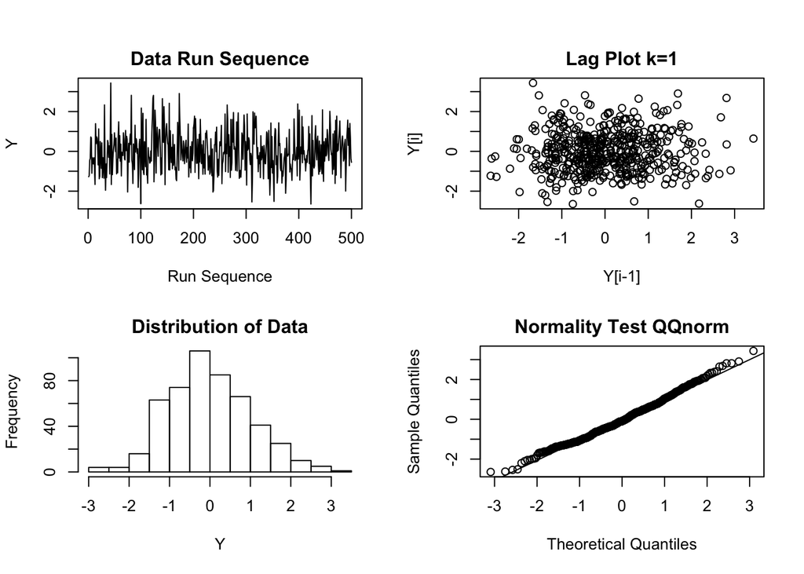

```r
t = 1:length(y)

par(mfrow = c(2, 2),
oma = c(0, 0, 2, 0),
mar = c(5.1, 4.1, 2.1, 2.1))

plot(t,y,ylab="Y",xlab="Run Sequence",type="l", main="Data Run Sequence")
plot(y,Lag(y, k=1),xlab="Y[i-1]",ylab="Y[i]", main="Lag Plot k=1")
hist(y, xlab="Y", main="Distribution of Data")
qqnorm(y,main="Normality Test QQnorm")
qqline(y)
```

The NFD.txt file appears to be highly nomally distributed by observing the histogram and the qqnorm graph which stands out very linear distribution.

```r
#UFD
x <- scan("UFD.txt")
head(x)
```

```
## [1] 0.100973 0.253376 0.520135 0.863467 0.354876 0.809590
```

```r
summary(x)
```

```
##    Min. 1st Qu.  Median    Mean 3rd Qu.    Max.
## 0.00249 0.25081 0.51836 0.50783 0.75912 0.99708
```

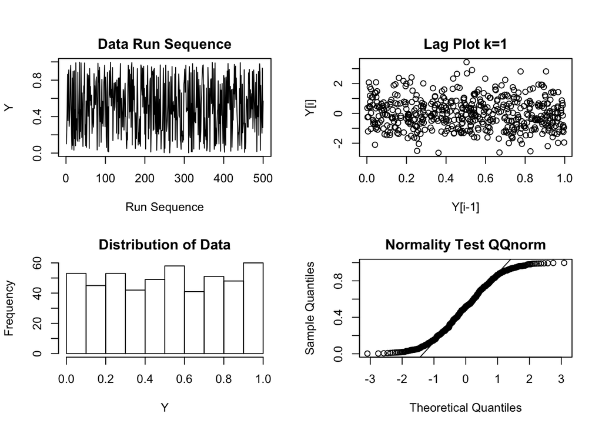

```r
a = 1:length(x)

par(mfrow = c(2, 2),
oma = c(0, 0, 2, 0),
mar = c(5.1, 4.1, 2.1, 2.1))

plot(a,x,ylab="Y",xlab="Run Sequence",type="l", main="Data Run Sequence")
plot(x,Lag(y, k=1),xlab="Y[i-1]",ylab="Y[i]", main="Lag Plot k=1")
hist(x, xlab="Y", main="Distribution of Data")
qqnorm(x,main="Normality Test QQnorm")
qqline(x)
```

The UFD.txt file appears to be not nomally distributed by observing the histogram the data is evenly distribute; and the qqnorm graph showing an none linear trend.